# Practical Machine Learning - Project Writeup

Jerold Paulson

Sunday, October 26, 2014

First we will define some functions that will be used to clean up the data We will remove all columns with NAs present.

```r
filterPml       <- function(x) { read.csv(x, na.strings = c("", "NA", "#DIV/0!") ) }
removeNAColumns     <- function(x) { x[ , colSums( is.na(x) ) < nrow(x) ] }
onlyCompleteRows       <- function(x) {x[,sapply(x, function(y) !any(is.na(y)))] }
```

Now we will read in the data from the csv files already downloaded from the web

```r
trainData      <- filterPml("pml-training.csv")
testData       <- filterPml("pml-testing.csv")
```

Next, we will remove columns 1,2,5 and 6 : 1,2 and 6 are not predictive variables, 5 is redundant

```r
training       <- trainData[,-c(1,2,5,6)]
testing        <- testData[,-c(1,2,5,6)]
```

Now, let’s partition the training set data for evaluative purposes into training and testing 70/30

```r
library(caret)
trainIndex  <- createDataPartition(training$classe, p=.70, list=FALSE)
trainingSubset <- training[ trainIndex,]
testingSubset  <- training[-trainIndex,]
```

Now filter out the NA Columns / incomplete rows

```r
trainingSubset <- onlyCompleteRows(removeNAColumns(trainingSubset))
testingSubset  <- onlyCompleteRows(removeNAColumns(testingSubset))
```

Next we do the actual training and look at the accuracy on the test subset of the practice data

```r
library(randomForest)
library(e1071)
boost <- train(classe~.,data=trainingSubset,method="gbm",verbose=FALSE,trControl=trainControl(method="cv",repeats=3))
```

Let’s now look at the results of the analysis and the quality of the predictions

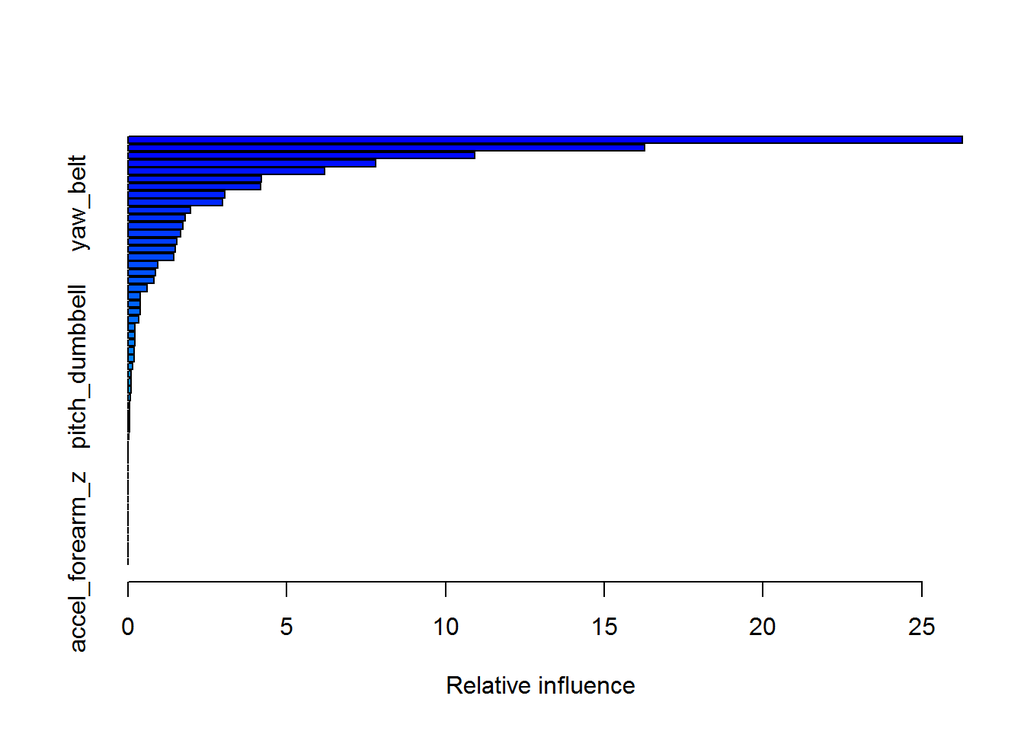

```
##                                       var  rel.inf
## raw_timestamp_part_1 raw_timestamp_part_1 26.27208
## roll_belt                       roll_belt 16.27458
## num_window                     num_window 10.91688
## pitch_forearm               pitch_forearm  7.79117
## magnet_dumbbell_z       magnet_dumbbell_z  6.19142
## roll_forearm                 roll_forearm  4.19489
## magnet_dumbbell_y       magnet_dumbbell_y  4.18017
## magnet_belt_z               magnet_belt_z  3.05190
## yaw_belt                         yaw_belt  2.97296
## roll_dumbbell               roll_dumbbell  1.96237
## accel_forearm_x           accel_forearm_x  1.80058
## pitch_belt                     pitch_belt  1.73742
## accel_dumbbell_y         accel_dumbbell_y  1.65542
## accel_dumbbell_z         accel_dumbbell_z  1.54940
## gyros_belt_z                 gyros_belt_z  1.48011
## gyros_dumbbell_y         gyros_dumbbell_y  1.44408
## yaw_arm                           yaw_arm  0.93121
## roll_arm                         roll_arm  0.87629
## accel_dumbbell_x         accel_dumbbell_x  0.81284
## accel_belt_z                 accel_belt_z  0.60391
## magnet_belt_x               magnet_belt_x  0.39607
## gyros_belt_y                 gyros_belt_y  0.39051
## magnet_arm_z                 magnet_arm_z  0.38900
## magnet_belt_y               magnet_belt_y  0.33807
## magnet_dumbbell_x       magnet_dumbbell_x  0.21559
## magnet_arm_y                 magnet_arm_y  0.21436
## magnet_arm_x                 magnet_arm_x  0.20680
## gyros_arm_y                   gyros_arm_y  0.20316
## magnet_forearm_x         magnet_forearm_x  0.18292
## pitch_dumbbell             pitch_dumbbell  0.14717
## accel_forearm_y           accel_forearm_y  0.10776
## total_accel_arm           total_accel_arm  0.09870
## magnet_forearm_z         magnet_forearm_z  0.09645
## gyros_dumbbell_z         gyros_dumbbell_z  0.07180
## accel_belt_y                 accel_belt_y  0.05807
## magnet_forearm_y         magnet_forearm_y  0.05270
## total_accel_dumbbell total_accel_dumbbell  0.04977
## yaw_dumbbell                 yaw_dumbbell  0.04525
## gyros_dumbbell_x         gyros_dumbbell_x  0.03615
## raw_timestamp_part_2 raw_timestamp_part_2  0.00000
## total_accel_belt         total_accel_belt  0.00000
## gyros_belt_x                 gyros_belt_x  0.00000
## accel_belt_x                 accel_belt_x  0.00000
## pitch_arm                       pitch_arm  0.00000
## gyros_arm_x                   gyros_arm_x  0.00000
## gyros_arm_z                   gyros_arm_z  0.00000
## accel_arm_x                   accel_arm_x  0.00000
## accel_arm_y                   accel_arm_y  0.00000
## accel_arm_z                   accel_arm_z  0.00000
## yaw_forearm                   yaw_forearm  0.00000
## total_accel_forearm   total_accel_forearm  0.00000
## gyros_forearm_x           gyros_forearm_x  0.00000
## gyros_forearm_y           gyros_forearm_y  0.00000
## gyros_forearm_z           gyros_forearm_z  0.00000
## accel_forearm_z           accel_forearm_z  0.00000
```

```r
print(summary(boost))
```

```r
print(confusionMatrix(predict(boost,newdata=testingSubset[,-56]),testingSubset$classe))
```

```
## Confusion Matrix and Statistics
##
##           Reference
## Prediction    A    B    C    D    E
##          A 1673    0    0    0    0
##          B    1 1137    1    0    0
##          C    0    2 1017    3    0
##          D    0    0    8  955    2
##          E    0    0    0    6 1080
##
## Overall Statistics
##
##                Accuracy : 0.996
##                  95% CI : (0.994, 0.998)
##     No Information Rate : 0.284
##     P-Value [Acc > NIR] : <2e-16
##
##                   Kappa : 0.995
##  Mcnemar's Test P-Value : NA
##
## Statistics by Class:
##
##                      Class: A Class: B Class: C Class: D Class: E
## Sensitivity             0.999    0.998    0.991    0.991    0.998
## Specificity             1.000    1.000    0.999    0.998    0.999
## Pos Pred Value          1.000    0.998    0.995    0.990    0.994
## Neg Pred Value          1.000    1.000    0.998    0.998    1.000
## Prevalence              0.284    0.194    0.174    0.164    0.184
## Detection Rate          0.284    0.193    0.173    0.162    0.184
## Detection Prevalence    0.284    0.194    0.174    0.164    0.185
## Balanced Accuracy       1.000    0.999    0.995    0.994    0.998
```

The overall accuracy, small p-value, and high sensitivity and specificity indicate that the predictive value should be very good.

Lastly, we find the actual predictions for the 20 test cases used for the assignment

```r
answer <- predict(boost, newdata=testData)
print(answer)
```

```
##  [1] B A B A A E D B A A B C B A E E A B B B
## Levels: A B C D E
```

It turns out that in the set of 20 test cases, the model predicted the correct class 100% of the time.